# Trade&Ahead - Problem Statement

## Context

The stock market is a powerful investment vehicle, offering opportunities for wealth creation, inflation protection, and tax benefits. However, choosing the right stocks requires thorough analysis, as financial metrics can be overwhelming. To optimize investment strategies, clustering techniques can be used to group stocks based on similar financial characteristics, helping investors build diversified and risk-adjusted portfolios

### Problem Statement

Investing in stocks requires careful analysis of financial metrics to build a diversified portfolio that minimizes risk and maximizes returns. With a vast number of stocks available in the market, manually analyzing each one to identify profitable investment opportunities is challenging. Investors need a systematic approach to categorize stocks based on their financial attributes, helping them make informed investment decisions.

### Data Dictionary

- Ticker Symbol: An abbreviation used to uniquely identify publicly traded shares of a particular stock on a particular stock market
- Company: Name of the company
- GICS Sector: The specific economic sector assigned to a company by the Global Industry Classification Standard (GICS) that best defines its business operations
- GICS Sub Industry: The specific sub-industry group assigned to a company by the Global Industry Classification Standard (GICS) that best defines its business operations
- Current Price: Current stock price in dollars
- Price Change: Percentage change in the stock price in 13 weeks
- Volatility: Standard deviation of the stock price over the past 13 weeks
- ROE: A measure of financial performance calculated by dividing net income by shareholders' equity (shareholders' equity is equal to a company's assets minus its debt)
- Cash Ratio: The ratio of a company's total reserves of cash and cash equivalents to its total current liabilities
- Net Cash Flow: The difference between a company's cash inflows and outflows (in dollars)
- Net Income: Revenues minus expenses, interest, and taxes (in dollars)
- Earnings Per Share: Company's net profit divided by the number of common shares it has outstanding (in dollars)
- Estimated Shares Outstanding: Company's stock is currently held by all its shareholders
- P/E Ratio: Ratio of the company's current stock price to the earnings per share
- P/B Ratio: Ratio of the company's stock price per share by its book value per share (book value of a company is the net difference between that company's total assets and total liabilities)

## Objective

Trade&Ahead, a financial consultancy firm, has provided stock market data, including stock prices and financial indicators. As a Data Scientist, the goal is to:

- Analyze stock data to identify key financial patterns.
- Cluster stocks using K-Means and Hierarchical clustering.
- Compare the clustering results to determine the best approach.
- Provide investment insights based on the identified stock groups.

# Data overview

```python
import pandas as pd

# Load the dataset
file_path = "/content/stock_data.csv"
df = pd.read_csv(file_path)
```

## Display basic information about the dataset

```python
df.head()
```

|  | Ticker Symbol | Security | GICS Sector | GICS Sub Industry | Current Price | Price Change | Volatility | ROE | Cash Ratio | Net Cash Flow | Net Income | Earnings Per Share | Estimated Shares Outstanding | P/E Ratio | P/B Ratio |
| --- | --- | --- | --- | --- | --- | --- | --- | --- | --- | --- | --- | --- | --- | --- | --- |
| 0 | AAL | American Airlines Group | Industrials | Airlines | 42.349998 | 9.999995 | 1.687151 | 135 | 51 | -604000000 | 7610000000 | 11.39 | 6.681299e+08 | 3.718174 | -8.784219 |
| 1 | ABBV | AbbVie | Health Care | Pharmaceuticals | 59.240002 | 8.339433 | 2.197887 | 130 | 77 | 51000000 | 5144000000 | 3.15 | 1.633016e+09 | 18.806350 | -8.750068 |
| 2 | ABT | Abbott Laboratories | Health Care | Health Care Equipment | 44.910000 | 11.301121 | 1.273646 | 21 | 67 | 938000000 | 4423000000 | 2.94 | 1.504422e+09 | 15.275510 | -0.394171 |
| 3 | ADBE | Adobe Systems Inc | Information Technology | Application Software | 93.940002 | 13.977195 | 1.357679 | 9 | 180 | -240840000 | 629551000 | 1.26 | 4.996437e+08 | 74.555557 | 4.199651 |
| 4 | ADI | Analog Devices, Inc. | Information Technology | Semiconductors | 55.320000 | -1.827858 | 1.701169 | 14 | 272 | 315120000 | 696878000 | 0.31 | 2.247994e+09 | 178.451613 | 1.059810 |

```python
df.info()
```

```
<class 'pandas.core.frame.DataFrame'>
RangeIndex: 340 entries, 0 to 339
Data columns (total 15 columns):
 #   Column                        Non-Null Count  Dtype
---  ------                        --------------  -----
 0   Ticker Symbol                 340 non-null    object
 1   Security                      340 non-null    object
 2   GICS Sector                   340 non-null    object
 3   GICS Sub Industry             340 non-null    object
 4   Current Price                 340 non-null    float64
 5   Price Change                  340 non-null    float64
 6   Volatility                    340 non-null    float64
 7   ROE                           340 non-null    int64
 8   Cash Ratio                    340 non-null    int64
 9   Net Cash Flow                 340 non-null    int64
 10  Net Income                    340 non-null    int64
 11  Earnings Per Share            340 non-null    float64
 12  Estimated Shares Outstanding  340 non-null    float64
 13  P/E Ratio                     340 non-null    float64
 14  P/B Ratio                     340 non-null    float64
dtypes: float64(7), int64(4), object(4)
memory usage: 40.0+ KB
```

```python
df.shape , df.describe()
```

```
((340, 15),
        Current Price  Price Change  Volatility         ROE  Cash Ratio  \
 count     340.000000    340.000000  340.000000  340.000000  340.000000
 mean       80.862345      4.078194    1.525976   39.597059   70.023529
 std        98.055086     12.006338    0.591798   96.547538   90.421331
 min         4.500000    -47.129693    0.733163    1.000000    0.000000
 25%        38.555000     -0.939484    1.134878    9.750000   18.000000
 50%        59.705000      4.819505    1.385593   15.000000   47.000000
 75%        92.880001     10.695493    1.695549   27.000000   99.000000
 max      1274.949951     55.051683    4.580042  917.000000  958.000000

        Net Cash Flow    Net Income  Earnings Per Share  \
 count   3.400000e+02  3.400000e+02          340.000000
 mean    5.553762e+07  1.494385e+09            2.776662
 std     1.946365e+09  3.940150e+09            6.587779
 min    -1.120800e+10 -2.352800e+10          -61.200000
 25%    -1.939065e+08  3.523012e+08            1.557500
 50%     2.098000e+06  7.073360e+08            2.895000
 75%     1.698108e+08  1.899000e+09            4.620000
 max     2.076400e+10  2.444200e+10           50.090000

        Estimated Shares Outstanding   P/E Ratio   P/B Ratio
 count                  3.400000e+02  340.000000  340.000000
 mean                   5.770283e+08   32.612563   -1.718249
 std                    8.458496e+08   44.348731   13.966912
 min                    2.767216e+07    2.935451  -76.119077
 25%                    1.588482e+08   15.044653   -4.352056
 50%                    3.096751e+08   20.819876   -1.067170
 75%                    5.731175e+08   31.764755    3.917066
 max                    6.159292e+09  528.039074  129.064585  )
```

Undertanding the dataset

- The dataset contains 340 rows and 15 columns.
- It includes categorical columns (e.g., Ticker Symbol, Security, GICS Sector, GICS Sub Industry).
- Numerical columns include stock prices, financial indicators (ROE, P/E Ratio, P/B Ratio, etc.), and earnings per share.
- There are no missing values (all columns have 340 non-null values).
- Some columns may require feature scaling before applying clustering.
- The P/B Ratio column has negative values, which should be investigated.

# Check for missing values and basic statistics:

```python
# Check for missing values
missing_values = df.isnull().sum()

# Summary statistics for numerical features
summary_stats = df.describe()

missing_values
```

|  | 0 |
| --- | --- |
| Ticker Symbol | 0 |
| Security | 0 |
| GICS Sector | 0 |
| GICS Sub Industry | 0 |
| Current Price | 0 |
| Price Change | 0 |
| Volatility | 0 |
| ROE | 0 |
| Cash Ratio | 0 |
| Net Cash Flow | 0 |
| Net Income | 0 |
| Earnings Per Share | 0 |
| Estimated Shares Outstanding | 0 |
| P/E Ratio | 0 |
| P/B Ratio | 0 |

**dtype:** int64

Therefore there are no missing values

# Univariate and Bivariate analysis

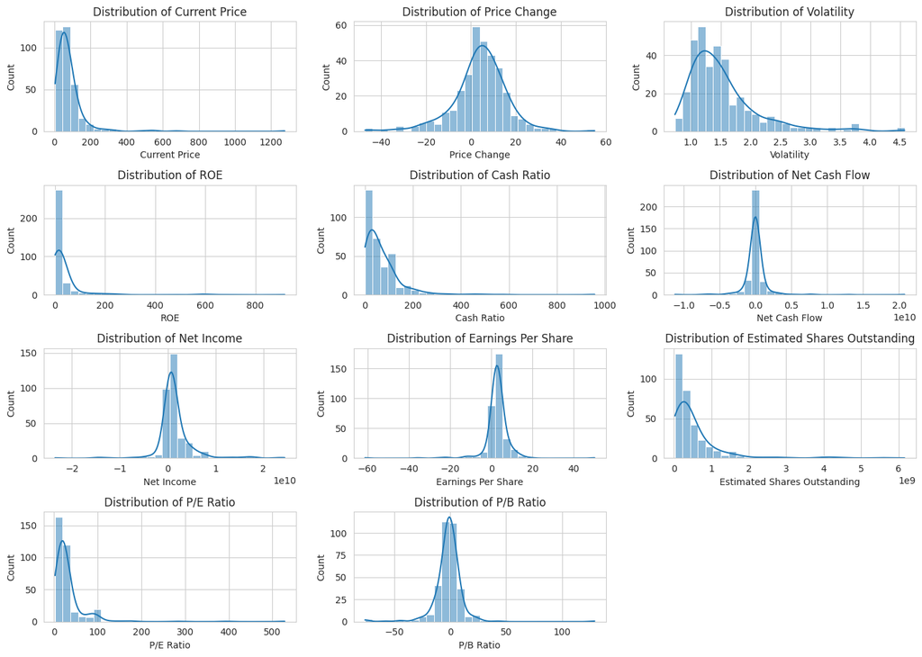

```python
import matplotlib.pyplot as plt
import seaborn as sns

# Set plot style
sns.set_style("whitegrid")

# Select numerical columns for analysis (excluding categorical ones)
numerical_cols = [
    "Current Price", "Price Change", "Volatility", "ROE", "Cash Ratio",
    "Net Cash Flow", "Net Income", "Earnings Per Share",
    "Estimated Shares Outstanding", "P/E Ratio", "P/B Ratio"
]

# Plot histograms for numerical features
plt.figure(figsize=(14, 10))
for i, col in enumerate(numerical_cols, 1):
    plt.subplot(4, 3, i)
    sns.histplot(df[col], bins=30, kde=True)
    plt.title(f"Distribution of {col}")

plt.tight_layout()
plt.show()
```

Observations (univariate analysis) :

- Current Price: Skewed distribution with a few very high-priced stocks.
- Price Change: Mostly centered around zero, but some stocks have extreme changes.
- Volatility: Right-skewed, indicating most stocks have low volatility, but a few are highly volatile.
- ROE (Return on Equity): Positively skewed, meaning a few stocks have extremely high ROE.
- Cash Ratio: Right-skewed, suggesting that most companies have low liquidity, but some hold large cash reserves.
- Net Cash Flow & Net Income: Show a long tail, meaning a few companies generate significantly higher cash flow/income.
- Earnings Per Share (EPS): Mostly low, with a few high values.
- P/E Ratio & P/B Ratio: Very high variability; some stocks have extremely high values, requiring potential outlier treatment.-

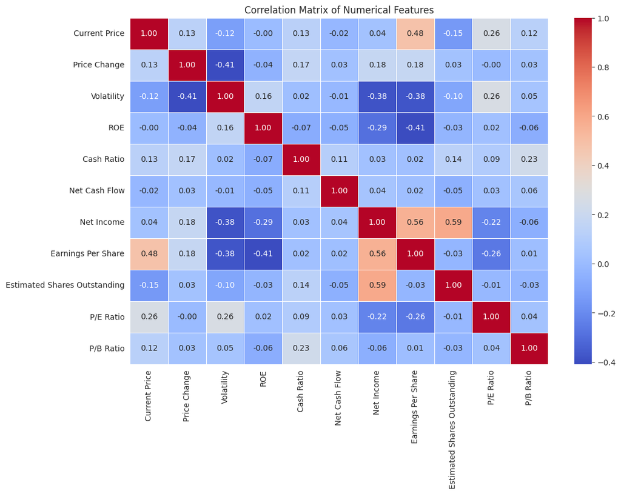

```python
# Compute the correlation matrix
corr_matrix = df[numerical_cols].corr()

# Plot heatmap of correlations
plt.figure(figsize=(12, 8))
sns.heatmap(corr_matrix, annot=True, cmap="coolwarm", fmt=".2f", linewidths=0.5)
plt.title("Correlation Matrix of Numerical Features")
plt.show()
```